# Lab 6 Assignment | PAF 516

Spatio-Temporal Analysis — LISA Trajectories & Space-Time Moran’s I

```r
# ── One-time course environment setup ─────────────────────────────────────
# Sentinel lives in user home (~/.paf516_ready) — persists across all lab
# folders. renv restores ONCE for the entire course, not once per lab.
# To force re-install: delete ~/.paf516_ready and re-render.
if (!file.exists("~/.paf516_ready")) {
  if (!requireNamespace("renv", quietly = TRUE)) install.packages("renv")
  tmp <- tempfile(fileext = ".lock")
  download.file(
    url      = "https://raw.githubusercontent.com/AntJam-Howell/paf-516-labs/main/renv.lock",
    destfile = tmp, mode = "wb"
  )
  renv::restore(lockfile = tmp, prompt = FALSE)
  file.create("~/.paf516_ready")
}

library(tidyverse)
library(tidycensus)
library(sf)
library(spdep)
library(viridis)
library(patchwork)
```

# Overview

**Rename this file** `Lab6_Assignment_YourLastName.qmd` before editing. Submit both `.qmd` and rendered `.html` to Canvas.

**Index:** 3 variables — poverty rate (C17002), unemployment rate (B23025), median income (B19013, reversed). All pulls use 2010 TIGER/Line tract boundaries.

**Checklist:**

- Renamed with your last name
- All pre-filled steps execute without error
- Q1 answer — min. 200 words with specific numbers
- Q2 code complete with output + comparison paragraph
- Q3 policy brief — min. 150 words, cites at least one reading
- Both `.qmd` and `.html` submitted to Canvas

# Step 1: Rebuild Dataset

```r
hardship_vars <- c(
  pov_below50   = "C17002_002",
  pov_50to99    = "C17002_003",
  pov_den       = "C17002_001",
  unemp_num     = "B23025_005",
  unemp_den     = "B23025_002",
  median_income = "B19013_001"
)
```

```r
# ── Data: Maricopa County tracts, 2013 + 2019 ACS ───
tract_2013_raw <- readRDS(url("https://raw.githubusercontent.com/AntJam-Howell/paf-516-labs/main/altlabs/Lab6/data/tract_2013_raw_RAW.rds"))
tract_2019_raw <- readRDS(url("https://raw.githubusercontent.com/AntJam-Howell/paf-516-labs/main/altlabs/Lab6/data/tract_2019_raw_RAW.rds"))
```

```r
widen_and_rate <- function(df) {
  df %>%
    select(-moe) %>%
    pivot_wider(names_from = variable, values_from = estimate) %>%
    mutate(poverty_rate = (pov_below50 + pov_50to99) / pov_den,
           unemp_rate   = unemp_num / unemp_den) %>%
    filter(!is.na(poverty_rate), !is.na(unemp_rate), !is.na(median_income))
}

tract_2013_wide <- widen_and_rate(tract_2013_raw)
tract_2019_wide <- widen_and_rate(tract_2019_raw)

vars_to_pool <- c("poverty_rate", "unemp_rate", "median_income")
r2013 <- tract_2013_wide %>% st_drop_geometry() %>% select(GEOID, all_of(vars_to_pool))
r2019 <- tract_2019_wide %>% st_drop_geometry() %>% select(GEOID, all_of(vars_to_pool))

pooled_stats <- map_dfr(vars_to_pool, function(v) {
  vals <- c(r2013[[v]], r2019[[v]])
  tibble(variable = v, mean = mean(vals, na.rm = TRUE), sd = sd(vals, na.rm = TRUE))
})

apply_pooled_z <- function(df, stats) {
  for (v in stats$variable) {
    pm <- stats$mean[stats$variable == v]; ps <- stats$sd[stats$variable == v]
    df[[paste0("z_", v)]] <- (df[[v]] - pm) / ps
  }
  df$z_median_income <- -1 * df$z_median_income
  df$hardship_index <- rowMeans(
    df[, c("z_poverty_rate", "z_unemp_rate", "z_median_income")], na.rm = TRUE)
  return(df)
}

r2013_z <- apply_pooled_z(r2013, pooled_stats)
r2019_z <- apply_pooled_z(r2019, pooled_stats)

change_df <- tract_2019_wide %>%
  select(GEOID, NAME) %>%
  left_join(r2019_z %>% select(GEOID, hardship_2019 = hardship_index), by = "GEOID") %>%
  inner_join(r2013_z %>% select(GEOID, hardship_2013 = hardship_index), by = "GEOID") %>%
  mutate(hardship_change = hardship_2019 - hardship_2013)

cat("Tracts:", nrow(change_df), "| Mean change:", round(mean(change_df$hardship_change), 3), "\n")
```

```
Tracts: 904 | Mean change: -0.483
```

# Step 2: Spatial Weights

```r
nb <- poly2nb(change_df, queen = TRUE)
w  <- nb2listw(nb, style = "W", zero.policy = TRUE)
```

# Step 3: LISA — 2013 and 2019

```r
classify_lisa <- function(x, w, p_thresh = 0.05) {
  lisa <- localmoran(x, w, zero.policy = TRUE)
  z    <- scale(x)[, 1]
  wz   <- lag.listw(w, z, zero.policy = TRUE)
  p    <- lisa[, "Pr(z != E(Ii))"]
  case_when(
    z > 0 & wz > 0 & p < p_thresh ~ "HH",
    z < 0 & wz < 0 & p < p_thresh ~ "LL",
    z > 0 & wz < 0 & p < p_thresh ~ "HL",
    z < 0 & wz > 0 & p < p_thresh ~ "LH",
    TRUE ~ "NS"
  )
}

change_df <- change_df %>%
  mutate(
    lisa_2013 = classify_lisa(hardship_2013, w),
    lisa_2019 = classify_lisa(hardship_2019, w)
  )

cat("2013 LISA:\n"); print(table(change_df$lisa_2013))
```

```
2013 LISA:
```

```
 HH  HL  LH  LL  NS
162   5   5 146 586
```

```r
cat("2019 LISA:\n"); print(table(change_df$lisa_2019))
```

```
2019 LISA:
```

```
 HH  HL  LH  LL  NS
175   3   1 149 576
```

# Step 4: Transition Matrix

```r
cat("── Transition matrix (rows = 2013, columns = 2019) ──\n")
```

```
── Transition matrix (rows = 2013, columns = 2019) ──
```

```r
print(table(`2013` = change_df$lisa_2013, `2019` = change_df$lisa_2019))
```

```
    2019
2013  HH  HL  LH  LL  NS
  HH 150   0   0   0  12
  HL   0   1   0   3   1
  LH   2   0   0   0   3
  LL   0   1   0 120  25
  NS  23   1   1  26 535
```

```r
cat("\n── Row proportions ──\n")
```

```
── Row proportions ──
```

```r
print(round(prop.table(
  table(`2013` = change_df$lisa_2013, `2019` = change_df$lisa_2019),
  margin = 1) * 100, 1))
```

```
    2019
2013   HH   HL   LH   LL   NS
  HH 92.6  0.0  0.0  0.0  7.4
  HL  0.0 20.0  0.0 60.0 20.0
  LH 40.0  0.0  0.0  0.0 60.0
  LL  0.0  0.7  0.0 82.2 17.1
  NS  3.9  0.2  0.2  4.4 91.3
```

# Step 5: Trajectory Classification and Map

```r
change_df <- change_df %>%
  mutate(trajectory = case_when(
    lisa_2013 == "HH" & lisa_2019 == "HH" ~ "Persistent HH",
    lisa_2013 != "HH" & lisa_2019 == "HH" ~ "Emerging HH",
    lisa_2013 == "HH" & lisa_2019 != "HH" ~ "Dissolving HH",
    lisa_2013 == "LL" & lisa_2019 == "LL" ~ "Persistent LL",
    lisa_2013 != "LL" & lisa_2019 == "LL" ~ "Emerging LL",
    lisa_2013 == "HL" | lisa_2019 == "HL" ~ "HL Outlier",
    TRUE ~ "Stable NS"
  ))

cat("── Trajectory distribution ──\n")
```

```
── Trajectory distribution ──
```

```r
change_df %>% st_drop_geometry() %>%
  count(trajectory, sort = TRUE) %>%
  mutate(pct = round(100 * n / sum(n), 1)) %>% print()
```

```
# A tibble: 7 × 3
  trajectory        n   pct
  <chr>         <int> <dbl>
1 Stable NS       564  62.4
2 Persistent HH   150  16.6
3 Persistent LL   120  13.3
4 Emerging LL      29   3.2
5 Emerging HH      25   2.8
6 Dissolving HH    12   1.3
7 HL Outlier        4   0.4
```

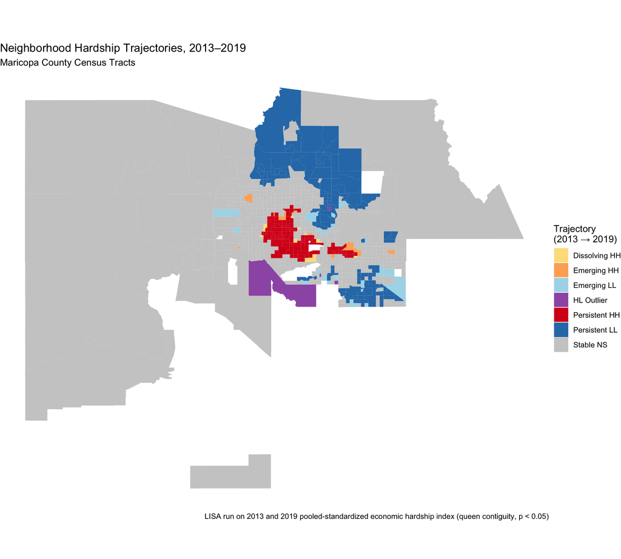

```r
traj_colors <- c(
  "Persistent HH" = "#D7191C", "Emerging HH"   = "#FDAE61",
  "Dissolving HH" = "#FEE08B", "Persistent LL"  = "#2C7BB6",
  "Emerging LL"   = "#ABD9E9", "HL Outlier"     = "#9E5BB4",
  "Stable NS"     = "#CCCCCC"
)

ggplot(change_df) +
  geom_sf(aes(fill = trajectory), color = NA) +
  scale_fill_manual(values = traj_colors,
                    name = "Trajectory\n(2013 → 2019)") +
  theme_void() +
  labs(title    = "Neighborhood Hardship Trajectories, 2013–2019",
       subtitle = "Maricopa County Census Tracts",
       caption  = "LISA run on 2013 and 2019 pooled-standardized economic hardship index (queen contiguity, p < 0.05)")
```

# Step 6: Space-Time Moran’s I

```r
set.seed(42)
moran_chg <- moran.mc(change_df$hardship_change, w, nsim = 999, zero.policy = TRUE)

cat("Space-Time Moran's I (on 2013→2019 change score):\n")
```

```
Space-Time Moran's I (on 2013→2019 change score):
```

```r
cat("  I =", round(moran_chg$statistic, 4), "\n")
```

```
  I = 0.1347
```

```r
cat("  p =", round(moran_chg$p.value, 4), "\n")
```

```
  p = 0.001
```

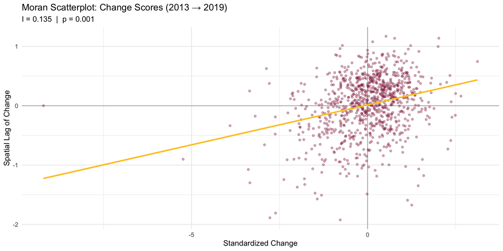

```r
z_chg  <- scale(change_df$hardship_change)[, 1]
wz_chg <- lag.listw(w, z_chg, zero.policy = TRUE)

ggplot(tibble(z = z_chg, wz = wz_chg), aes(x = z, y = wz)) +
  geom_hline(yintercept = 0, color = "gray70") +
  geom_vline(xintercept = 0, color = "gray70") +
  geom_point(alpha = 0.35, size = 1.2, color = "#8C1D40") +
  geom_smooth(method = "lm", se = FALSE, color = "#FFC627", linewidth = 1) +
  theme_minimal() +
  labs(title    = "Moran Scatterplot: Change Scores (2013 → 2019)",
       subtitle = paste0("I = ", round(moran_chg$statistic, 3),
                         "  |  p = ", round(moran_chg$p.value, 3)),
       x = "Standardized Change", y = "Spatial Lag of Change")
```